# Practice Midterm

Johnson ODEJIDE

2023-03-01

## (a)

```r
X <- c(221, 400,    300,    400,    200,    260,    300,    375,    210,    400,    200,    344)
Y <- c(33,  42, 37, 53, 22, 37, 40, 42, 25, 52, 30, 42)

dt <- data.frame(X, Y)
# dt
```

Use and show R code to produce a scatter plot for the bivariate data given above. Indicate if the scatter plot is showing a definitive positive or negative trend for the data.

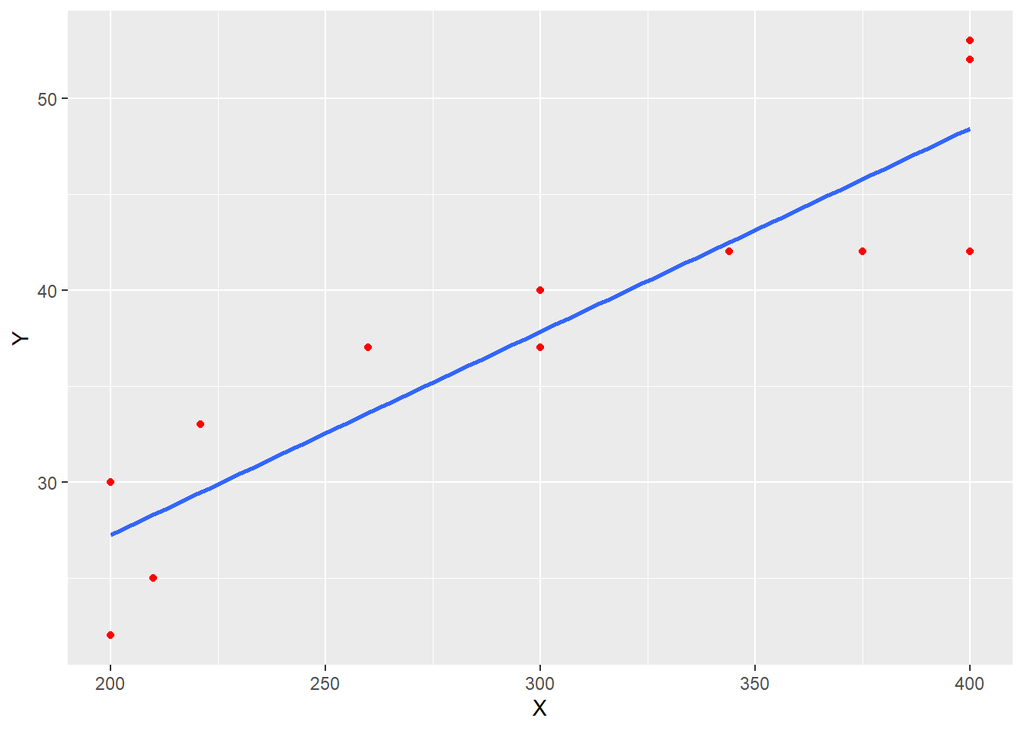

```r
dt %>%
  ggplot(aes(x = X, y = Y)) +
  geom_point(color = 'red') +
  geom_smooth(method = 'lm', se = FALSE, formula = y ~ x)
```

The scatter plot showed a positive relationship, although this relationship is not perfectly definite as a little curve is also noticeable at some points.

## (b)

Use and show R code to produce a linear model for the bivariate data shown above (use the lm method). Interpret the slope of your model.

```r
lm.fit <- lm(Y ~ X)
summary(lm.fit)
```

```
##
## Call:
## lm(formula = Y ~ X)
##
## Residuals:
##     Min      1Q  Median      3Q     Max
## -6.4169 -3.4166  0.8421  3.4393  4.5831
##
## Coefficients:
##             Estimate Std. Error t value Pr(>|t|)
## (Intercept)  6.06311    4.65678   1.302    0.222
## X            0.10588    0.01498   7.068 3.42e-05 ***
## ---
## Signif. codes:  0 '***' 0.001 '**' 0.01 '*' 0.05 '.' 0.1 ' ' 1
##
## Residual standard error: 4.061 on 10 degrees of freedom
## Multiple R-squared:  0.8332, Adjusted R-squared:  0.8165
## F-statistic: 49.96 on 1 and 10 DF,  p-value: 3.424e-05
```

```r
# Yhat = 6.063 + 0.106X
# On average, for each additional increase in 1 unit of X, there is an increase in Y by 0.106 units.
```

On average, for each additional increase in X by 1, there is an increase in Y by 0.106.

## (c)

About 83.32% of the variation in Y can be explained by the linear regression model.

## (d)

```r
confint(lm.fit, '(Intercept)', level = 0.95)
```

```
##                 2.5 %   97.5 %
## (Intercept) -4.312842 16.43906
```

## (e)

```r
lm.fit.res <- residuals(lm.fit)
lm.fit.res[2]
```

```
##        2
## -6.41687
```

## (f)

```r
lm.fit.res
```

```
##          1          2          3          4          5          6          7
##  3.5364385 -6.4168704 -0.8284297  4.5831296 -5.2399889  3.4069466  2.1715703
##          8          9         10         11         12
## -3.7697602 -3.2988330  3.5831296  2.7600111 -0.4873436
```

## (g)

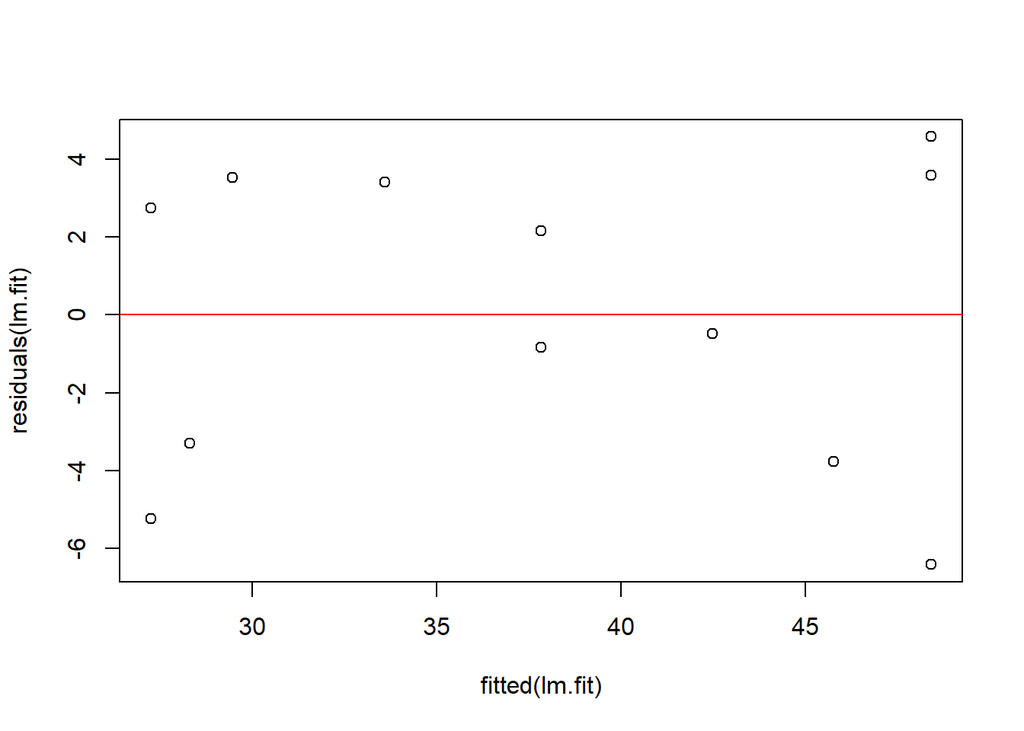

```r
plot(fitted(lm.fit), residuals(lm.fit))
# plot(lm.fit$fitted.values, lm.fit$residuals)
abline(0, 0, col='red')
```

```r
# plot(lm.fit$fitted.values, lm.fit$residuals)
# abline(0, 0, col='red')
```

The residual vs fitted plot shows signs of constant variance and no outliers in the data. Also shows signs of normality as there are equal number of data points above and below the 0 line in no specific pattern. It seems it is distributed but the data appears to be a roughly straight line.

## (h)

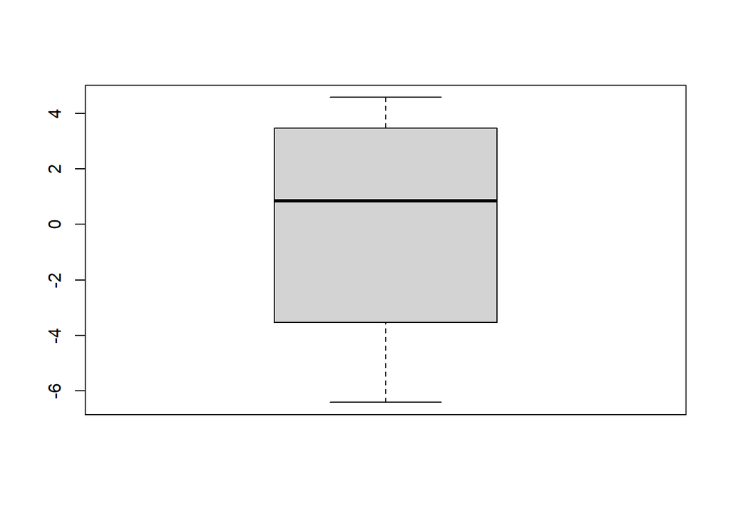

```r
boxplot(residuals(lm.fit))
```

The boxplot does not indicate the presence of an outlier

## (i)

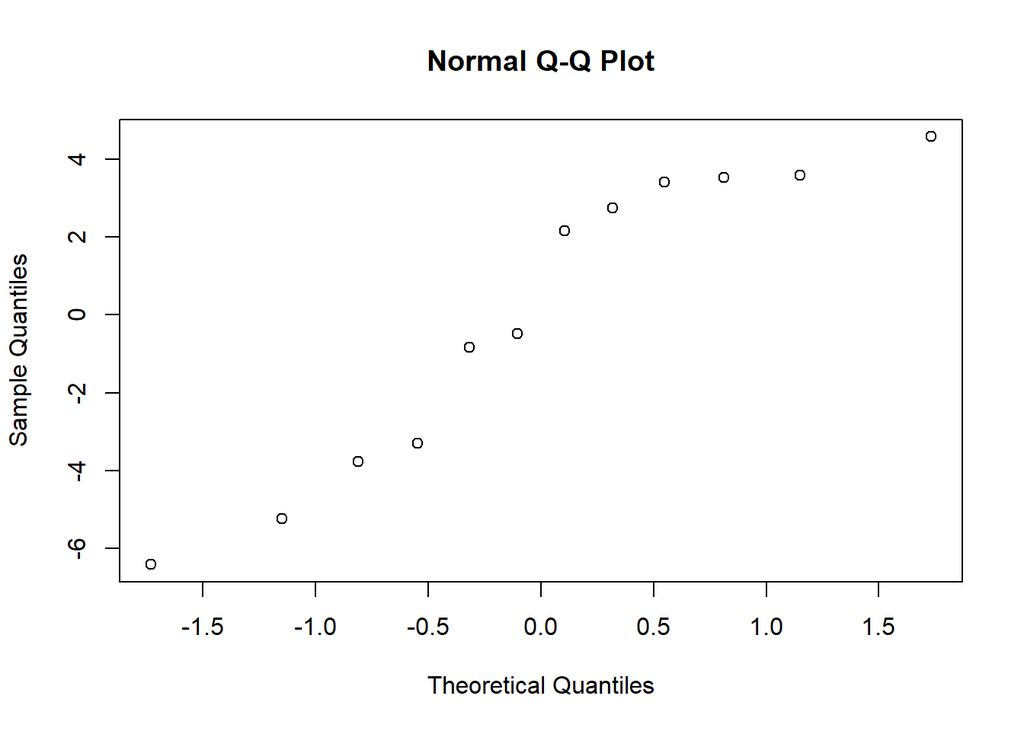

```r
qqnorm(residuals(lm.fit))
```

```r
# qqline(residuals(lm.fit))
```

## (j)

```r
anova(lm.fit)
```

```
## Analysis of Variance Table
##
## Response: Y
##           Df Sum Sq Mean Sq F value    Pr(>F)
## X          1 823.97  823.97  49.956 3.424e-05 ***
## Residuals 10 164.94   16.49
## ---
## Signif. codes:  0 '***' 0.001 '**' 0.01 '*' 0.05 '.' 0.1 ' ' 1
```

```r
## 16.49
```

The value that estimates the variance of the population linear model is 16.49

## (k)

```r
f.value <- 49.956

f.critical <- qf(p = 0.05, df1 = 1, df2 = 10, lower.tail = FALSE)

print(paste("F value = ", f.value, " and F Critical = ", f.critical))
```

```
## [1] "F value =  49.956  and F Critical =  4.96460274373071"
```

```r
ifelse(f.value > f.critical, "Reject the null hypothesis", "Fail to reject the null hypothesis")
```

```
## [1] "Reject the null hypothesis"
```

## (l)

```r
ym <- matrix(Y, ncol = 1, byrow = TRUE)
xm <- matrix(c(
  1, 221,
  1, 400,
  1, 300,
  1, 400,
  1, 200,
  1, 260,
  1, 300,
  1, 375,
  1, 210,
  1, 400,
  1, 200,
  1, 344), ncol = 2, byrow = T)

t(xm) -> transposeXm

transposeXm%*%xm-> Product1

solve(Product1)%*%transposeXm%*%ym
```

```
##           [,1]
## [1,] 6.0631075
## [2,] 0.1058844
```

```r
solve(Product1)%*%transposeXm%*%ym -> interceptandslope
# interceptandslope
```

`B0 = 6.0631075`

`B1 = 0.1058844`

These results align with what was earlier gotten from fitting the linear regression model with the lm() function.

# Part 2

## (a)

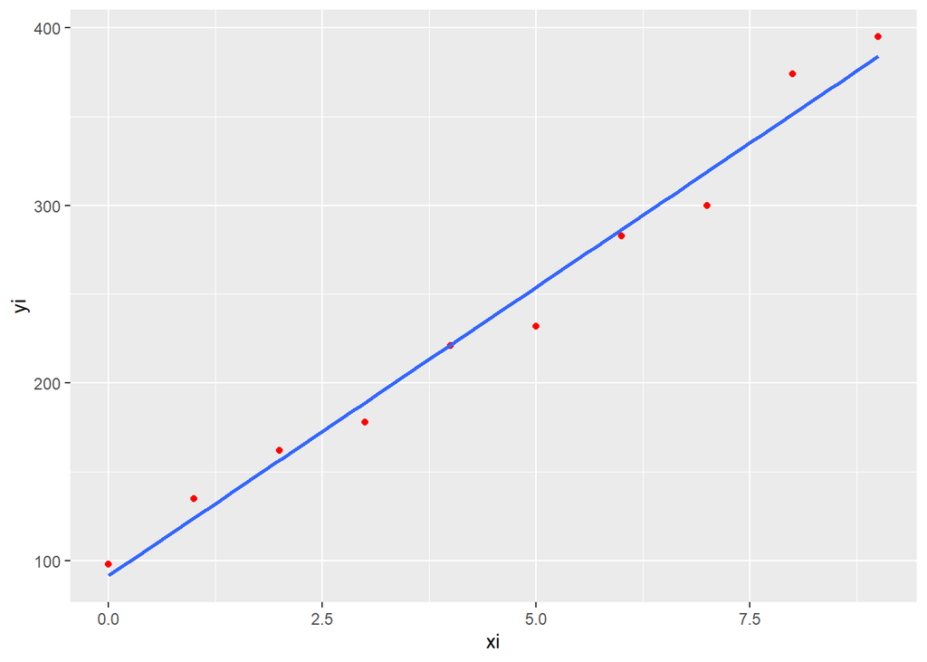

```r
xi <- c(0:9)
yi <- c(98, 135, 162, 178, 221, 232, 283, 300, 374, 395)

xcom <- data.frame(xi, yi)

xcom %>%
  ggplot(aes(x = xi, y = yi)) +
  geom_point(color = 'red') +
  geom_smooth(method = 'lm', se = F, formula= y ~ x)
```

The linear relationship seems to be appropriate, showing a positive linear relationship.

## (b)

```r
box_cox <- boxcox(yi ~ xi)
```

[figure not shown]

```r
lambda <- box_cox$x[which.max(box_cox$y)]
lambda
```

```
## [1] 0.5050505
```

```r
new_model <- lm(((yi^lambda-1)/lambda) ~ xi)
new_model
```

```
##
## Call:
## lm(formula = ((yi^lambda - 1)/lambda) ~ xi)
##
## Coefficients:
## (Intercept)           xi
##      18.810        2.212
```

The appropriate power transformation of y is y^0.5050505

```r
Y_trans <- lm(sqrt(yi) ~ xi)
summary(Y_trans)
```

```
##
## Call:
## lm(formula = sqrt(yi) ~ xi)
##
## Residuals:
##      Min       1Q   Median       3Q      Max
## -0.47447 -0.30811  0.01549  0.29541  0.46781
##
## Coefficients:
##             Estimate Std. Error t value Pr(>|t|)
## (Intercept) 10.26093    0.21290   48.20 3.80e-11 ***
## xi           1.07629    0.03988   26.99 3.83e-09 ***
## ---
## Signif. codes:  0 '***' 0.001 '**' 0.01 '*' 0.05 '.' 0.1 ' ' 1
##
## Residual standard error: 0.3622 on 8 degrees of freedom
## Multiple R-squared:  0.9891, Adjusted R-squared:  0.9878
## F-statistic: 728.4 on 1 and 8 DF,  p-value: 3.826e-09
```

sqrt(yhat) = 10.26093 + 1.07629x